# STAT 331 Portfolio

## Program Efficiency

**PE-1: I can write concise code which does not repeat itself.**

- using a single function call with multiple inputs (rather than multiple function calls)

```r
# challenege-4
ca_preschool <- ca_childcare |>
    select(
        county_name,
        study_year,
        mc_preschool,
        mfcc_preschool
    ) |>
    pivot_longer(
        cols = c(mc_preschool, mfcc_preschool),
        names_to = "care setting",
        values_to = "price"
    ) |>
    mutate(
        `care setting` = fct_recode(
            `care setting`,
            "Care Center" = "mc_preschool",
            "Family/ In-Home" = "mfcc_preschool"
        ),
        county_name = str_remove(county_name, " County$")
    )
```

- using `across()`

```r
#lab-8-q1
rescale_01 <- function(x) {
    if (!is.numeric(x)) {
        stop("Input vector must be numeric")
    }
    if (length(x) <= 1) {
        stop("Input vector length must be greater than 1")
    }

    range_vals <- range(x, na.rm = TRUE)
    min_val <- range_vals[1]
    max_val <- range_vals[2]

    # Apply the rescaling formula
    (x - min_val) / (max_val - min_val)
}

rescale_column <- function(data, cols) {
  if (!is.data.frame(data)) {
    stop("Input must be a data frame")
  }

  data |>
    mutate(
      #here---------->
      across(
        .cols = {{ cols }},
        .fns = ~rescale_01(.x)
        )
    )
}
```

- using functions from the `map()` family

```r
#lab-10-q1
set.seed(67)

results <- map_int(
              .x = 1:10000,
              .f = ~randomBabies(n_babies = 4)
            )
```

**PE-2: I can write functions to reduce repetition in my code.**

- Example 1: Function that operates on vectors

```r
# lab-8-q1
rescale_01 <- function(x) {
    if (!is.numeric(x)) {
        stop("Input vector must be numeric")
    }
    if (length(x) <= 1) {
        stop("Input vector length must be greater than 1")
    }

    range_vals <- range(x, na.rm = TRUE)
    min_val <- range_vals[1]
    max_val <- range_vals[2]

    # Apply the rescaling formula
    (x - min_val) / (max_val - min_val)
}
```

- Example 2: Function that operates on data frames

```r
# lab-8-q1
rescale_column <- function(data, cols) {
  if (!is.data.frame(data)) {
    stop("Input must be a data frame")
  }

  data |>
    mutate(across(
      .cols = {{ cols }},
      .fns = ~rescale_01(.x)
      )
    )
}
```

- Example 3: Function that operates on vectors *or* data frames

```r
#lab-8-q2
pivot_table <- function(data, row, col) {
  if (!is.data.frame(data)) {
    stop("Input must be a data frame")
  }

  data |>
    count({{ row }}, {{ col }}) |>
    pivot_wider(
      names_from = {{ col }},
      values_from = n,
      values_fill = 0
      ) |>
    janitor::adorn_totals(where = c("row", "col"))
}
```

**PE-3:I can use iteration to reduce repetition in my code.**

- using `across()`

```r
#lab-3-q5
teacher_evals_clean <- teacher_evals |>
  rename(sex = gender) |>
  filter(
    no_participants >= 10,
    !is.na(no_participants)
    ) |>
  select(
    course_id, teacher_id, question_no, no_participants, resp_share,
    SET_score_avg, percent_failed_cur, academic_degree, seniority, sex
    ) |>
  mutate (
    across(
      .cols = c(teacher_id, question_no, no_participants, seniority),
      .fns  = as.integer
    )
  )
```

- using a `map()` function with **one** input (e.g., `map()`, `map_chr()`, `map_dbl()`, etc.)

```r
#lab-9-q2
surveys |>
  map_chr(class) |>
  enframe(name = "Variable", value = "Data Type") |>
  kable()
```

```r
# lab-10-q10
set.seed(331)

ci_dat <- map(
            .x = 1:1000,
            .f = ~mycifun(beta0 = 3, beta1 = 0.5, n = 100)
          )
```

**PE-4: I can use modern tools when carrying out my analysis.**

- I can use functions which are not superseded or deprecated

```r
#lab-4-q7

# Stack overflow led me to https://dplyr.tidyverse.org/reference/recode.html but it was
# superceded by https://dplyr.tidyverse.org/reference/case_match.html

childcare_age_df <- ca_childcare %>%
    select(
        county_name,
        region,
        study_year,
        mc_infant,
        mc_toddler,
        mc_preschool
    ) %>%
    pivot_longer(
        cols = c(
            mc_infant,
            mc_toddler,
            mc_preschool
        ),
        names_to = "age",
        values_to = "price"
    ) %>%
    mutate(
        age = case_match(
            age,
            "mc_infant" ~ "Infant",
            "mc_toddler" ~ "Toddler",
            "mc_preschool" ~ "Preschool",
            .default = age
        )
```

- I can connect a data wrangling pipeline into a `ggplot()`

```r
# challenege-4
price_summary |>
    filter(county_name %in% top_counties) |>
    ggplot(aes(
        x = reorder(county_name, median_price),
        y = median_price,
        fill = `care setting`
    )) +
```

## Data Simulation & Statisical Models

**DSSM-1: I can simulate data from a *variety* of probability models.**

- Example 1

```r
#lab-10-q4
# define slope and intercept parameters
intercept = 2
slope = 1

# generate x vector
x <- runif(n = 100, min = 0, max = 1)

# generate noise `ep` vector
ep <- rnorm(n = 100, mean = 0, sd = 1)

# generate outcome from population model
y = intercept + (x * slope) + ep

# create an "observed data" dataframe with only the x and y vectors
observed_data <- tibble(x = x, y = y)
```

- Example 2

```r
#lab-10-q1
randomBabies <- function(n_babies){
  correct <- 1:n_babies
  random_assign <- sample(1:n_babies)
  num_correct <- sum(correct == random_assign)
  return(num_correct)
}
```

**DSSM-2: I can conduct common statistical analyses in R.**

- Example 1
- *This works, but did you need to make a contingency table? Could you have input these vectors directly into the chisq.test() function?*

```r
#challenge-3-q3
chisq.test(
  teacher_evals_compare$SET_level,
  teacher_evals_compare$sen_level
  )
```

- Example 2

```r
#lab04-q9
reg_mod1 <- lm(
  mc_infant ~ mhi_2018,
  data = ca_childcare
  )
summary(reg_mod1)
```

- Example 3

```r
#lab-2-q17

species_mod <- aov(
  weight ~ species,
  data = surveys
  )

summary(species_mod)
```

## Revising My Thinking

For the majority of my submissions, I have revised my code and submission based on the feedback that has been provided. I try to remember to use this feedback in all my future code too.

## Extending My Thinking

I used stack overflow and documentation to help me in answering some questions. I feel like this helped me more than ChatGPT because in CS there are always multiple ways to the same problem, and doing this showed me tons of different functions and ways that I could get to the same answer. Throughout my labs and challenges, I attached links to resources that I used to get to my answer. I used a lot of these same functions again in later labs/projects where I recalled them and thought they would be correct to use.

## Peer Support & Collaboration

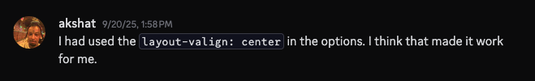

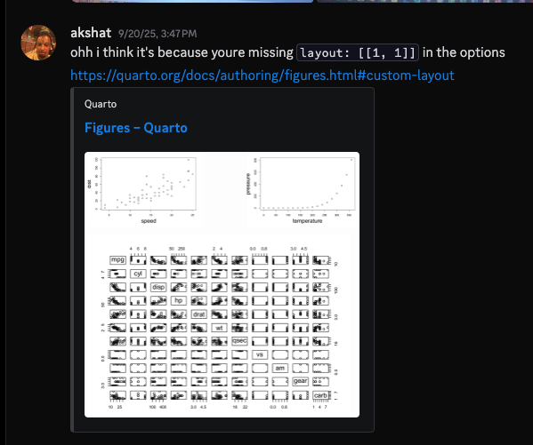

At first in the pair programming activities it was really difficult to me to stop myself from going ahead when I was the computer/typer role. Being a CS major, I feel like I was able to connect some of what I do in my classes/projects to the data analysis tasks and so I was able to process the questions faster than my partner was. However, as we did more pair programming activities I’ve learned to respect my partner as everyone learns differently and I need to slow down so that my partner can also process their ideas. Also, sometimes their ideas are more efficient than the idea I would’ve typed out if I was going ahead of them - so it’s worth following what they say and then discussing their ideas with them.